Page under construction - course not finalized

# **Filtering a low quality sample**

**Application of a PCA-based technique for filtering**

**Motivation:**

Quality control and filtering is the most important steps of single cell data analysis. Allowing low quality cells into your analysis will compromise/mislead your conclusions by adding hundreds of meaningless data points to your workflow. The main sources of low quality cells are

- broken cells for which some of their transcripts get lost
- cells isolated together with too much ambient RNA
- missing cell during isolation (e.g. empty droplet in microfluidic machines)
- multiple cells isolated together (multiplets, usually only two cells - doublets)

A typical way of filtering cells is to look at thresholds for various QC measures. Here, we apply also a PCA technique that looks at all QC measures available at the same time.

**Learning objectives:**

- Understand and discuss QC issues and measures from single cell data
- Explore QC graphs and set filtering tools and thresholds
- Understand and apply PCA outliers detection
- Analyze the results of QC filters and evaluate necessity for different filtering

**Execution time: 40 minutes**

**Import the packages**

```python
import scanpy as sc
import pandas as pd
import scvelo as scv
import numpy as np
import seaborn as sns
import matplotlib.pyplot as plt
import sklearn
```

import scanpy as sc import pandas as pd import scvelo as scv import numpy as np import seaborn as sns import matplotlib.pyplot as plt import sklearn

```python
sample_1 = sc.read_h5ad('../../../Data/notebooks_data/sample_1.h5ad')
```

sample_1 = sc.read_h5ad('../../../Data/notebooks_data/sample_1.h5ad')

```python
sample_1
```

sample_1

```
AnnData object with n_obs × n_vars = 23794 × 36601
    obs: 'initial_size_spliced', 'initial_size_unspliced', 'initial_size'
    var: 'gene_ids', 'feature_types', 'Accession', 'Chromosome', 'End', 'Start', 'Strand'
    layers: 'ambiguous', 'spliced', 'unspliced'
```

## Read the kneeplot (for 10X data with cellranger)

The `cellRanger` aligner used for 10X data provides a report for the user. This contains a lot of useful statistics including the so-called knee plot, shown below on the right side of the picture. The knee plot is very useful to have an overview of the data quality. The x axis represents the barcode of each cell (ordered by decreasing number of UMIs), while the y axis shows how many UMIs are present in each cells. The line is blue where data points have been identified as cells of good quality, and it becomes lighter when the data point is less likely to be a cell.

[figure not shown]

This knee plot is clearly representing a low quality dataset (look at the three typical scenarios below). Moreover, we have a very low proportion of reads in each cell. Filtering this dataset might not keep many cells at the end of the process.

[figure not shown]

*Representation of knee plots scenario. From the authors of the cellBender package.*

**Percentage of mitocondrial genes**

We calculate the percentage of mitocondrial genes into each cell. A high percentage denotes the possibility that material from broken cells has been captured during cell isolation, and then sequenced. Mitocondrial percentage is not usually calculated by `scanpy`, because there is need for an identifier for mitocondrial genes, and there is not a standard one. In our case, we look at genes that contain `MT-` into their ID, and calculate their transcript proportion into each cell. We save the result as an observation into `.obs['perc_mito']`

```python
sample_1.X = np.array(sample_1.X.todense()).copy()
```

sample_1.X = np.array(sample_1.X.todense()).copy()

```python
MT = ['MT' in i for i in sample_1.var_names]
perc_mito = np.sum( sample_1[:,MT].X, 1 ) / np.sum( sample_1.X, 1 )
sample_1.obs['perc_mito'] = perc_mito.copy()
```

MT = ['MT' in i for i in sample_1.var_names] perc_mito = np.sum( sample_1[:,MT].X, 1 ) / np.sum( sample_1.X, 1 ) sample_1.obs['perc_mito'] = perc_mito.copy()

```python
sc.pp.calculate_qc_metrics(sample_1, inplace=True)
```

sc.pp.calculate_qc_metrics(sample_1, inplace=True)

## Visualize and evaluate quality measures

We can do some plots to have a look at quality measures combined together

**Counts vs Genes:** this is a typical plot, where you look at the total transcripts per cells (x axis) and detected genes per cell (y axis). Usually, those two measures grow together. Points with a lot of transcripts and genes might be multiplets (multiple cells sequenced together as one), while very few transcripts and genes denote the presence of only ambient RNA or very low quality sequencing of a cell. Below, the dots are coloured based on the percentage of mitocondrial transcripts. Note how a high proportion is often on cells with very low transcripts and genes (bottom left corner of the plot)

```python
plt.rcParams['figure.figsize'] = (8,6)
sc.pl.scatter(sample_1, x='total_counts', y='n_genes_by_counts', color='perc_mito',
              title ='Nr of transcripts vs Nr detected genes, coloured by mitocondrial content',
              size=30)
```

plt.rcParams['figure.figsize'] = (8,6) sc.pl.scatter(sample_1, x='total_counts', y='n_genes_by_counts', color='perc_mito', title ='Nr of transcripts vs Nr detected genes, coloured by mitocondrial content', size=30)

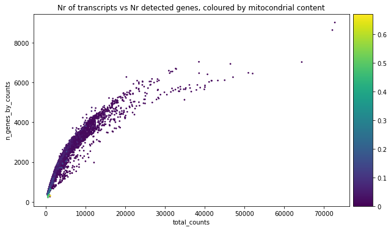

```python
sc.pl.scatter(sample_1[sample_1.obs['total_counts']<10000], x='total_counts', y='n_genes_by_counts', color='perc_mito',
              title ='Nr of transcripts vs Nr detected genes, coloured by mitocondrial content (Zoom)',
             size=30)
```

sc.pl.scatter(sample_1[sample_1.obs['total_counts']<10000], x='total_counts', y='n_genes_by_counts', color='perc_mito', title ='Nr of transcripts vs Nr detected genes, coloured by mitocondrial content (Zoom)', size=30)

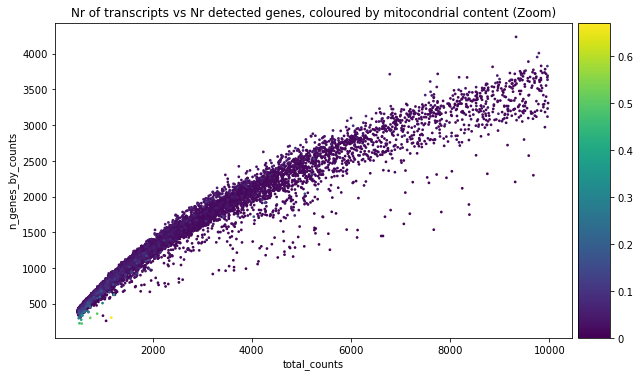

```python
ax = sns.distplot(sample_1.obs['total_counts'], bins=50)
ax.set_title('Cells Transcripts distribution')
```

ax = sns.distplot(sample_1.obs['total_counts'], bins=50) ax.set_title('Cells Transcripts distribution')

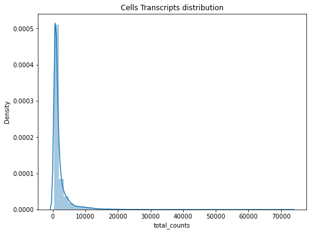

```python
ax = sns.distplot(sample_1.obs['n_genes_by_counts'], bins=50)
ax.set_title('Distribution of detected genes per cell')
```

ax = sns.distplot(sample_1.obs['n_genes_by_counts'], bins=50) ax.set_title('Distribution of detected genes per cell')

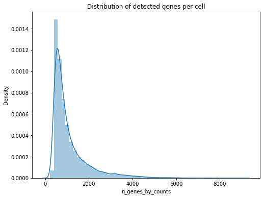

In this dataset there are few cell with a high percentage of mitocondrial content. Those are precisely 77 if we set 0.1 (that is 10%) as a treshold. A value between 10% and 20% is the usual standard when filtering single cell datasets.

```python
#subsetting to see how many cells have percentage of mitocondrial genes above 10%
sample_1[ sample_1.obs['perc_mito']>0.1, : ].shape
```

#subsetting to see how many cells have percentage of mitocondrial genes above 10% sample_1[ sample_1.obs['perc_mito']>0.1, : ].shape

```
(77, 36601)
```

```python
ax = sns.distplot(sample_1.obs['perc_mito'], bins=50)
ax.set_title('Distribution of mitocondrial content per cell')
```

ax = sns.distplot(sample_1.obs['perc_mito'], bins=50) ax.set_title('Distribution of mitocondrial content per cell')

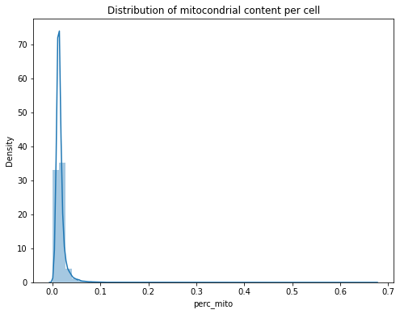

## PCA-based filtering

Now we calculate a PCA on a set of quality measures, and find out the outliers in the resulting PCA projections. We remove these outliers from the dataset: they will be data points with an anomalous subset of quality measures. This technique is rewritten from the `R` package `scran`. The script below does the filtering and plots the PCA with the outliers represented by circles.

```python
import numpy as np
from sklearn.decomposition import PCA
from sklearn.preprocessing import scale
from sklearn.ensemble import IsolationForest
plt.rcParams['figure.figsize'] = (16,6)

#write here which quality measures you want to use
df = sample_1.obs[ ['n_genes_by_counts', 'total_counts',
                    'perc_mito', 'pct_counts_in_top_50_genes'] ]

df2 = scale(df, axis=0)

pca = PCA(n_components=2)

Y = pca.fit_transform(df2)

clf = IsolationForest(random_state=0)

pred = clf.fit_predict(df2)

sample_1 = sample_1[pred==1].copy()

pred = pd.Categorical(pred)
pred = pred.rename_categories(['Outlier','Cell'])
df['Category'] = pred

sns.scatterplot(Y[:,0],Y[:,1], hue = df.total_counts, style = df.Category,
                palette="Blues", sizes=(20, 200), hue_norm=(0, 100))
```

import numpy as np from sklearn.decomposition import PCA from sklearn.preprocessing import scale from sklearn.ensemble import IsolationForest plt.rcParams['figure.figsize'] = (16,6) #write here which quality measures you want to use df = sample_1.obs[ ['n_genes_by_counts', 'total_counts', 'perc_mito', 'pct_counts_in_top_50_genes'] ] df2 = scale(df, axis=0) pca = PCA(n_components=2) Y = pca.fit_transform(df2) clf = IsolationForest(random_state=0) pred = clf.fit_predict(df2) sample_1 = sample_1[pred==1].copy() pred = pd.Categorical(pred) pred = pred.rename_categories(['Outlier','Cell']) df['Category'] = pred sns.scatterplot(Y[:,0],Y[:,1], hue = df.total_counts, style = df.Category, palette="Blues", sizes=(20, 200), hue_norm=(0, 100))

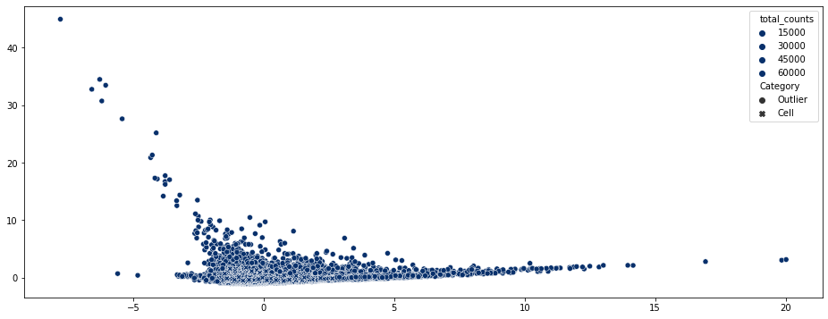

we have removed around 3000 cells

```python
sample_1
```

sample_1

```
AnnData object with n_obs × n_vars = 20984 × 36601
    obs: 'initial_size_spliced', 'initial_size_unspliced', 'initial_size', 'perc_mito', 'n_genes_by_counts', 'log1p_n_genes_by_counts', 'total_counts', 'log1p_total_counts', 'pct_counts_in_top_50_genes', 'pct_counts_in_top_100_genes', 'pct_counts_in_top_200_genes', 'pct_counts_in_top_500_genes'
    var: 'gene_ids', 'feature_types', 'Accession', 'Chromosome', 'End', 'Start', 'Strand', 'n_cells_by_counts', 'mean_counts', 'log1p_mean_counts', 'pct_dropout_by_counts', 'total_counts', 'log1p_total_counts'
    layers: 'ambiguous', 'spliced', 'unspliced'
```

## Choosing thresholds

We use some thresholds by looking at the previous QC plots. Those will eventually remove some remaining low quality cells.

```python
MIN_COUNTS = 5000   #minimum number of transcripts per cell
MAX_COUNTS = 15000  #maximum number of transcripts per cell
MIN_GENES = 2500    #minimum number of genes per cell
MAX_GENES = 6000    #maximum number of genes per cell
MAX_MITO = .1       #mitocondrial percentage treshold
```

MIN_COUNTS = 5000 #minimum number of transcripts per cell MAX_COUNTS = 15000 #maximum number of transcripts per cell MIN_GENES = 2500 #minimum number of genes per cell MAX_GENES = 6000 #maximum number of genes per cell MAX_MITO = .1 #mitocondrial percentage treshold

We can do some subsetting to zoom into the plots we did before

```python
plt.rcParams['figure.figsize'] = (8,6)
sc.pl.scatter(sample_1[ sample_1.obs['total_counts']<MAX_COUNTS ],
              x='total_counts', y='n_genes_by_counts', color='perc_mito',
              title =f'Nr of transcripts vs Nr detected genes, coloured by mitocondrial content\nsubsetting with threshold MAX_COUNTS={MAX_COUNTS}',
             size=30)
```

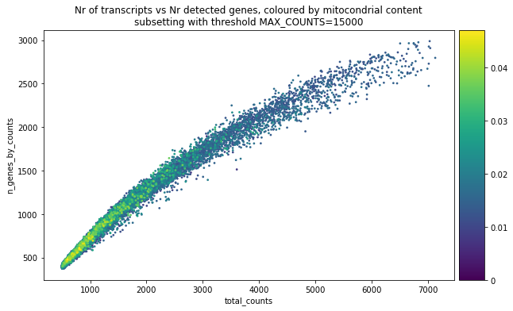

```python
sc.pl.scatter(sample_1[ sample_1.obs['n_genes_by_counts'] > MIN_GENES ],
              x='total_counts', y='n_genes_by_counts', color='perc_mito',
              title =f'Nr of transcripts vs Nr detected genes, coloured by mitocondrial content\nsubsetting with treshold MIN_GENES={MIN_GENES}',
             size=30)
```

sc.pl.scatter(sample_1[ sample_1.obs['n_genes_by_counts'] > MIN_GENES ], x='total_counts', y='n_genes_by_counts', color='perc_mito', title =f'Nr of transcripts vs Nr detected genes, coloured by mitocondrial content\nsubsetting with treshold MIN_GENES={MIN_GENES}', size=30)

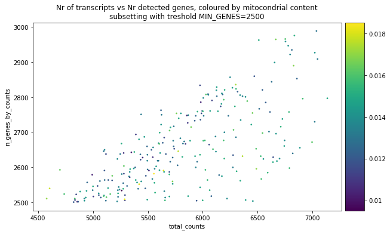

The following commands filter using the chose tresholds. Again, scanpy does not do the mitocondrial QC filtering, so we do that on our own by subsetting the data.

```python
sc.preprocessing.filter_cells(sample_1, max_counts=MAX_COUNTS)

sc.preprocessing.filter_cells(sample_1, min_counts=MIN_COUNTS)

sc.preprocessing.filter_cells(sample_1, min_genes=MIN_GENES)

sc.preprocessing.filter_cells(sample_1, max_genes=MAX_GENES)

sc.preprocessing.filter_genes(sample_1, min_cells=10)

sample_1 = sample_1[sample_1.obs['perc_mito']<MAX_MITO].copy()
```

We can see how only a low number of cells is left.

```python
sample_1
```

sample_1

```
AnnData object with n_obs × n_vars = 243 × 10203
    obs: 'initial_size_spliced', 'initial_size_unspliced', 'initial_size', 'perc_mito', 'n_genes_by_counts', 'log1p_n_genes_by_counts', 'total_counts', 'log1p_total_counts', 'pct_counts_in_top_50_genes', 'pct_counts_in_top_100_genes', 'pct_counts_in_top_200_genes', 'pct_counts_in_top_500_genes', 'n_…
    var: 'gene_ids', 'feature_types', 'Accession', 'Chromosome', 'End', 'Start', 'Strand', 'n_cells_by_counts', 'mean_counts', 'log1p_mean_counts', 'pct_dropout_by_counts', 'total_counts', 'log1p_total_counts', 'n_cells'
    layers: 'ambiguous', 'spliced', 'unspliced'
```

## Doublet filtering

Another important step consists in filtering out multiplets. Those are in the almost totality of the cases doublets, because triplets and above multiplets are extremely rare. Read [this more technical blog post](https://liorpachter.wordpress.com/2019/02/07/sub-poisson-loading-for-single-cell-rna-seq/) for more explanations about this.

The external tool `scrublet` simulates doublets by putting together the transcripts of random pairs of cells from the dataset. Then it assigns a score to each cell in the data, based on the similarity with the simulated doublets. An `expected_doublet_rate` of 0.06 (6%) is quite a typical value for single cell data, but if you have a better estimate from laboratory work, microscope imaging or a specific protocol/sequencing machine, you can also tweak the value. `random_state` is a number choosing how the simulations are done. using a specific random state means that you will always simulate the same doublets whenever you run this code. This allows you to reproduce exactly the same results every time and is a great thing for reproducibility in your own research.

```python
sc.external.pp.scrublet(sample_1,
                        expected_doublet_rate=0.06,
                        random_state=12345)
```

sc.external.pp.scrublet(sample_1, expected_doublet_rate=0.06, random_state=12345)

```
Automatically set threshold at doublet score = 0.24
Detected doublet rate = 7.0%
Estimated detectable doublet fraction = 17.5%
Overall doublet rate:
	Expected   = 6.0%
	Estimated  = 40.0%
```

```python
sns.distplot(sample_1.obs['doublet_score'])
```

sns.distplot(sample_1.obs['doublet_score'])

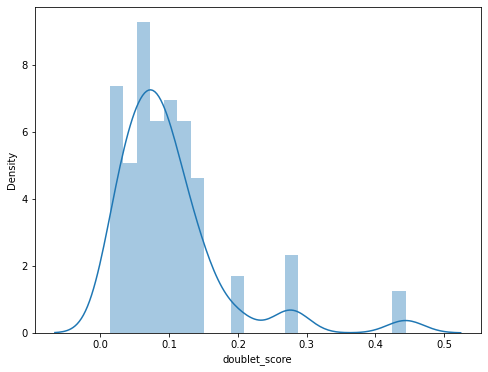

We can choose 0.1 as filtering treshold for the few detected doublets or alternatively use the automatic selection of doublets by the algorithm. We will choose the last option and use the automatically chosen doublets.

```python
sample_1 = sample_1[np.invert(sample_1.obs['predicted_doublet'])].copy()
```

sample_1 = sample_1[np.invert(sample_1.obs['predicted_doublet'])].copy()

## Evaluation of filtering

A quite basic but easy way to look at the results of our filtering is to normalize and plot the dataset on some projections. Here we use a standard normalization technique that consists of:

- **TPM normalization**: the transcripts of each cell are normalized, so that their total amounts to the same value. This should make cells more comparable independently of how many transcripts their has been retained during cell isolation.
- **Logarithmization**: the logarithm of the normalized transcripts is calculated. This reduce the variability of transcripts values and highlights variations due to biological factors.
- **Standardization**: Each gene is standardized across all cells. This is useful for example for projecting the data onto a PCA.

```python
# TPM normalization and storage of the matrix
sc.pp.normalize_per_cell(sample_1)
sample_1.layers['umi_tpm'] = sample_1.X.copy()

# Logarithmization and storage
sc.pp.log1p(sample_1)
sample_1.layers['umi_log'] = sample_1.X.copy()

# Select some of the most meaningful genes to calculate the PCA plot later
# This must be done on logarithmized values
sc.pp.highly_variable_genes(sample_1, n_top_genes=15000)

# save the dataset
sample_1.write('../Data/notebooks_data/sample_1.filt.h5ad')

# standardization and matrix storage
sc.pp.scale(sample_1)
sample_1.layers['umi_gauss'] = sample_1.X.copy()
```

# TPM normalization and storage of the matrix sc.pp.normalize_per_cell(sample_1) sample_1.layers['umi_tpm'] = sample_1.X.copy() # Logarithmization and storage sc.pp.log1p(sample_1) sample_1.layers['umi_log'] = sample_1.X.copy() # Select some of the most meaningful genes to calculate the PCA plot later # This must be done on logarithmized values sc.pp.highly_variable_genes(sample_1, n_top_genes=15000) # save the dataset sample_1.write('../Data/notebooks_data/sample_1.filt.h5ad') # standardization and matrix storage sc.pp.scale(sample_1) sample_1.layers['umi_gauss'] = sample_1.X.copy()

Now we calculate the PCA projection

```python
sc.preprocessing.pca(sample_1, svd_solver='arpack', random_state=12345)
```

sc.preprocessing.pca(sample_1, svd_solver='arpack', random_state=12345)

We can look at the PCA plot and color it by some quality measure and gene expression. Even though we filtered a lot, there is still some structure left. But with so few cells, the dataset is not worth of usage, since the other samples have thousands of cells of better quality

```python
sc.pl.pca(sample_1, color=['total_counts','SYCP1'])
```

sc.pl.pca(sample_1, color=['total_counts','SYCP1'])

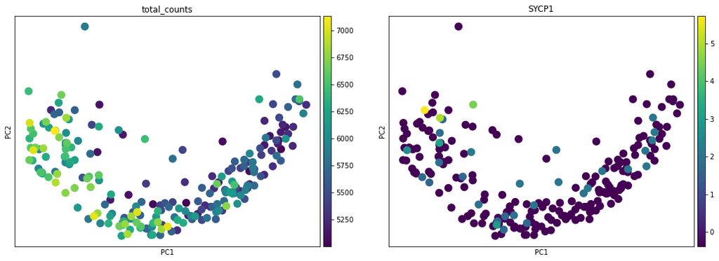

We plot the variance ratio to see how each component of the PCA changes in variability. Small changes in variability denote that the components are mostly modeling noise in the data. We can choose a threshold (for example 15 PCA components) to be used in all algorithms that use PCA to calculate any quantity.

```python
sc.plotting.pca_variance_ratio(sample_1)
```

sc.plotting.pca_variance_ratio(sample_1)

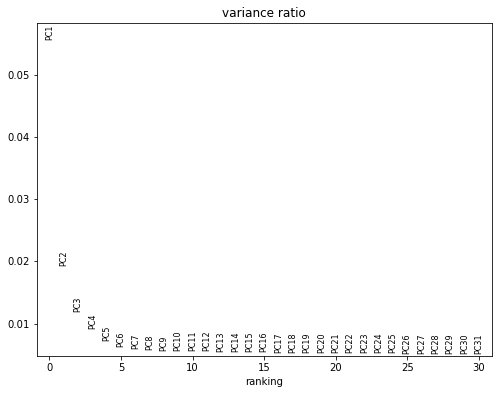

We project the data using the UMAP algorithm. This is very good in preserving the structure of a dataset in low dimension, if any is present. We first calculate the neighbors of each cell (that is, its most similar cells), those are then used for the UMAP. The neighbors are calculated using the PCA matrix instead of the full data matrix, so we can choose the number of PCA components to use (parameter `n_pcs`). Many algorithms work on the PCA, so you will see the parameter used again in other places.

```python
sc.pp.neighbors(sample_1, n_pcs=15, random_state=12345)
```

sc.pp.neighbors(sample_1, n_pcs=15, random_state=12345)

```python
sc.tools.umap(sample_1, random_state=54321)
```

sc.tools.umap(sample_1, random_state=54321)

```python
sc.plotting.umap(sample_1, color=['total_counts','SYCP1'])
```

sc.plotting.umap(sample_1, color=['total_counts','SYCP1'])

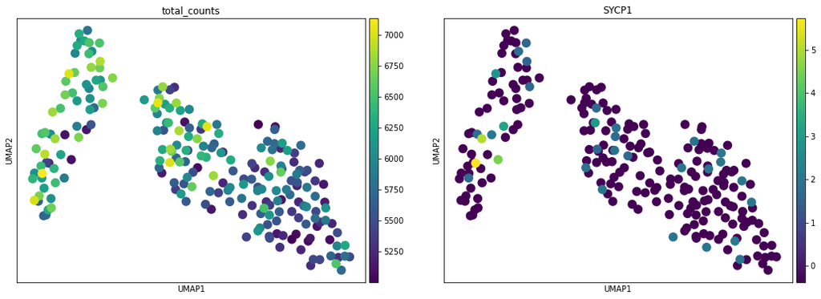

## Wrapping up

We have looked through a low quality dataset, and applied PCA-based and threshold-based filterings. The filtering resulted in removing almost all available data points.